# Experiment 7 academics’ beliefs about human knowledge

```r
rm(list = ls(all = TRUE))
#load needed libraries
library(FactoMineR)
library(psych)
library(gdata)
library(data.table)
library(tidyr)
library(reshape2)
library(ggfortify)
library(qdapTools)
library(lm.beta)
##### change current group to select dataset
##### note:separate scripts for Experiments 3 and 4b
currentgroup = c("scholar")
currentcondition = c("natural","humanity","mind")
## prep; load data files & set parameters
masterdata  = read.table(file = "/Users/jennywang/Google Drive/Museum/mathitude/data/alternative analyses/mathitudemaster.csv", sep=",",header=TRUE, na.strings="")
data = subset(masterdata,masterdata$Group %in% currentgroup)
data = subset(data,data$Condition %in% currentcondition)
data_t = data
data_t[,24:37]=(as.numeric(data[,24:37]=="T"|data[,24:37]=="O"))
cols<- c(a.born="royalblue1",b.mature="skyblue2",c.teach="darkorange1",d.observe="orange")
read <- c("how.read")
sensory <- c("how.see","how.hear")
core <- c("how.color","how.depth","how.face","how.gravity","how.objperm","how.number","how.help")
types <- c("read","sensory","core")
allitems <-c("read","help","number","objperm","gravity","face","depth","color","hear","see")
allhows <-c("how.read","how.help","how.number","how.objperm","how.gravity","how.face","how.depth","how.color","how.hear","how.see")
allwhen<-c("when.read","when.help","when.number","when.objperm","when.gravity","when.face","when.depth","when.color","when.hear","when.see")
empirical = c(6, 0.5, 0.0055,0.29, 0.25, 0.0019, 0.0054, 0.33, 0.0027, 0.052)
####################################
### overall descriptives based on timeline choices and proportion responses for plotting
des_m = describeBy(data,group=NULL,na.rm=TRUE)
```

[output not shown]

```r
dat_m = data[,24:33]
table_m= mtabulate(dat_m)
time_m = des_m[10:19,]
rownames(time_m) <- c("read","help","number","objperm","gravity","face","depth","color","hear","see")
how_m = table_m/rowSums(table_m,na.rm=FALSE)
colnames(how_m) <- c("b.mature","a.born","d.observe","c.teach")
summ_m = cbind(time_m,how_m)
summ_m$Category.num = c(10,9,8,7,6,5,4,3,2,1)
summ_m$learning=summ_m$d.observe+summ_m$c.teach
##age estimates based on actual findings
summ_m$emp.age = empirical
##converting timeline choice mean/se to age estimate
summ_m$mean.estimate = 0.13*exp(0.78*summ_m$mean)
summ_m$se.estimate = 0.13*exp(0.78*summ_m$se)
summ_m$confIV1.estimate = summ_m$mean.estimate-1.96*summ_m$se.estimate
summ_m$confIV2.estimate = summ_m$mean.estimate+1.96*summ_m$se.estimate
summ_m$overratio=summ_m$mean.estimate/summ_m$emp.age
##averages based on timeline choices
summ_core=colMeans(summ_m[2:8,])
summ_sense=colMeans(summ_m[9:10,])
summ_3 = rbind(summ_m[1,],summ_core,summ_sense)
summ_3$Category.num=c(3,2,1)
summ_3$age.ratio=summ_3$mean.estimate/summ_3$emp.age
rownames(summ_3)<-c("read","core","sensory")
summ_m[,-c(1:18)]
```

|  | learning | emp.age | mean.estimate | se.estimate | confIV1.estimate | confIV2.estimate | overratio |
| --- | --- | --- | --- | --- | --- | --- | --- |
| read | 0.997448980 | 6.0000 | 2.8039501 | 0.1331613 | 2.54295394 | 3.0649462 | 0.467325 |
| help | 0.898550725 | 0.5000 | 1.6273927 | 0.1337751 | 1.36519347 | 1.8895920 | 3.254785 |
| number | 0.664556962 | 0.0055 | 1.0412576 | 0.1339479 | 0.77871974 | 1.3037954 | 189.319556 |
| objperm | 0.782178218 | 0.2900 | 1.0311546 | 0.1331713 | 0.77013878 | 1.2921705 | 3.555706 |
| gravity | 0.940860215 | 0.2500 | 0.7971433 | 0.1330134 | 0.53643708 | 1.0578495 | 3.188573 |
| face | 0.432132964 | 0.0019 | 0.4763889 | 0.1342946 | 0.21317141 | 0.7396063 | 250.730978 |
| depth | 0.560606061 | 0.0054 | 0.8049535 | 0.1341369 | 0.54204508 | 1.0678618 | 149.065454 |
| color | 0.284482759 | 0.3300 | 0.5428779 | 0.1334091 | 0.28139613 | 0.8043597 | 1.645085 |
| hear | 0.002645503 | 0.0027 | 0.2886124 | 0.1307550 | 0.03233251 | 0.5448922 | 106.893464 |
| see | 0.010526316 | 0.0520 | 0.2925789 | 0.1309986 | 0.03582172 | 0.5493361 | 5.626518 |

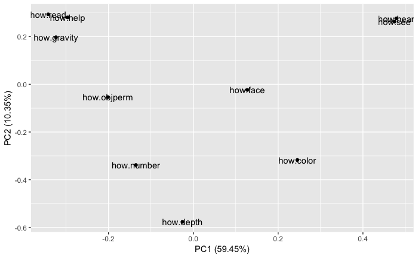

```r
# ## PCA ######### ########### cluster analysis ###########
pcadata=data_t[,24:33] #mturk how
pcadata=na.omit(pcadata)
pcadata=t(pcadata)
autoplot(prcomp(pcadata), label=TRUE)
```

```r
av.emp = mean(c(0.5, 0.0055,0.29, 0.25, 0.0019, 0.0054, 0.33))
emps = c(6,0,av.emp)
how.summ = data_t[,c(1:9,38,39,40,41)]
output = data.frame(files=NULL)
summ.output = data.frame(files=NULL)
for(i in c(1:nrow(data_t))){
  how.sub = how.summ[i,]
  sum.sub = as.data.frame(lapply(how.sub, rep, 3))
  how.sub = as.data.frame(lapply(how.sub, rep, 10))
  for (k in c(1:10)){
    how.sub$Item[k] <- allhows[k]
    how.sub$How[k] <- data_t[[paste("how.",allitems[k],sep="")]][i]
    how.sub$When[k] <- data_t[[paste("when.",allitems[k],sep="")]][i]
    how.sub$When.estimate[k]<-0.13*exp(0.78*how.sub$When[k])
    }
  for(j in c(1:3)){
    sum.sub$Type[j]<-types[j]
    sum.sub$How[j] <- mean(how.sub$How[how.sub$Item %in% eval(parse(text = types[j]))],na.rm=TRUE)
    sum.sub$When[j] <- mean(how.sub$When[how.sub$Item %in% eval(parse(text = types[j]))],na.rm=TRUE)
    sum.sub$When.estimate[j]<-mean(how.sub$When.estimate[how.sub$Item %in% eval(parse(text = types[j]))],na.rm=TRUE)
    sum.sub$w.bias[j]<-sum.sub$When.estimate[j]-emps[j]
  }
  output = rbind(output,how.sub)
  summ.output = rbind(summ.output,sum.sub)
}
summ.output$Condition = as.factor(as.character(summ.output$Condition=="mind"))
summ.output$Type = as.factor(as.character(summ.output$Type))
summ.output$Gender = as.factor(as.character(summ.output$Gender))
summ.output$Parent = as.factor(as.character(summ.output$Parent))
summ.output$SubID = as.factor(as.character(summ.output$SubID))
summ.output$Education = as.factor(as.character(as.integer(summ.output$Education)>2)) #all academics had college+ degree, so changed to graduate+
descr.how <-describeBy(summ.output$How,list(summ.output$Type),na.rm=TRUE,mat=TRUE)
descr.how$confIV1 = descr.how$mean-1.96*descr.how$se
descr.how$confIV2 = descr.how$mean+1.96*descr.how$se
descr.how[,c(2,5,16,17)]
```

|  | group1 | mean | confIV1 | confIV2 |
| --- | --- | --- | --- | --- |
| X11 | core | 0.644056570 | 0.6180232509 | 0.67008989 |
| X12 | read | 0.997448980 | 0.9924489796 | 1.00244898 |
| X13 | sensory | 0.008883249 | 0.0006701132 | 0.01709638 |

```r
descr.when <-describeBy(summ.output$When,list(summ.output$Type),na.rm=TRUE,mat=TRUE)
descr.when$confIV1 = descr.when$mean-1.96*descr.when$se
descr.when$confIV2 = descr.when$mean+1.96*descr.when$se
descr.when$mean.estimate = 0.13*exp(0.78*descr.when$mean)
descr.when$se.estimate = 0.13*exp(0.78*descr.when$se)
descr.when$confIV1.estimate = descr.when$mean.estimate-1.96*descr.when$se.estimate
descr.when$confIV2.estimate = descr.when$mean.estimate+1.96*descr.when$se.estimate
descr.when[,c(2,18:21)]
```

|  | group1 | mean.estimate | se.estimate | confIV1.estimate | confIV2.estimate |
| --- | --- | --- | --- | --- | --- |
| X11 | core | 0.8379000 | 0.1322444 | 0.57870099 | 1.0970990 |
| X12 | read | 2.8039501 | 0.1331613 | 2.54295394 | 3.0649462 |
| X13 | sensory | 0.2905889 | 0.1306417 | 0.03453124 | 0.5466465 |

```r
descr.when$mean.estimate[1]/av.emp
```

```
[1] 4.241611
```

```r
output.core=subset(summ.output,summ.output$Type=="core")
t.test(output.core$How,mu=0.5)
```

```
    One Sample t-test

data:  output.core$How
t = 10.846, df = 398, p-value < 2.2e-16
alternative hypothesis: true mean is not equal to 0.5
95 percent confidence interval:
 0.6179443 0.6701688
sample estimates:
mean of x
0.6440566
```

```r
t.test(w.bias~Type,paired=TRUE,data=subset(summ.output,summ.output$Type!="read"))
```

```
    Paired t-test

data:  w.bias by Type
t = 26.437, df = 399, p-value < 2.2e-16
alternative hypothesis: true difference in means is not equal to 0
95 percent confidence interval:
 0.5353987 0.6214235
sample estimates:
mean of the differences
              0.5784111
```

```r
t.test(w.bias~Type,paired=TRUE,data=subset(summ.output,summ.output$Type!="sensory"))
```

```
    Paired t-test

data:  w.bias by Type
t = 48.52, df = 399, p-value < 2.2e-16
alternative hypothesis: true difference in means is not equal to 0
95 percent confidence interval:
 3.580584 3.882992
sample estimates:
mean of the differences
               3.731788
```

```
Call:
lm(formula = When.estimate ~ Condition + Gender + Age + Education +
    Parent, data = output.core)

Standardized Coefficients::
  (Intercept) ConditionTRUE       GenderM           Age EducationTRUE       ParentY
   0.00000000   -0.11930703   -0.06649752   -0.16787075    0.01351185   -0.02380592
```

```
Call:
lm(formula = When.estimate ~ Condition + Gender + Age + Education +
    Parent, data = output.core)

Residuals:
     Min       1Q   Median       3Q      Max
-0.69045 -0.29140 -0.08532  0.18165  2.32206

Coefficients:
               Estimate Std. Error t value Pr(>|t|)
(Intercept)    1.431651   0.112181  12.762   <2e-16 ***
ConditionTRUE -0.105024   0.044310  -2.370   0.0183 *
GenderM       -0.063020   0.047218  -1.335   0.1828
Age           -0.006771   0.002749  -2.463   0.0142 *
EducationTRUE  0.015226   0.061160   0.249   0.8035
ParentY       -0.023106   0.061737  -0.374   0.7084
---
Signif. codes:  0 ‘***’ 0.001 ‘**’ 0.01 ‘*’ 0.05 ‘.’ 0.1 ‘ ’ 1

Residual standard error: 0.4337 on 388 degrees of freedom
  (6 observations deleted due to missingness)
Multiple R-squared:  0.04371,   Adjusted R-squared:  0.03139
F-statistic: 3.547 on 5 and 388 DF,  p-value: 0.003787
```

|  | group1 | mean | confIV1 | confIV2 |
| --- | --- | --- | --- | --- |
| X11 | FALSE | 1.104605 | 1.0421340 | 1.167077 |
| X12 | TRUE | 1.035426 | 0.9754952 | 1.095357 |

|  | group1 | mean | confIV1 | confIV2 |
| --- | --- | --- | --- | --- |
| X11 | FALSE | 1.108183 | 1.004823 | 1.211542 |
| X12 | TRUE | 1.061063 | 1.013305 | 1.108822 |

```
Call:
lm(formula = How ~ Condition + Gender + Age + Education + Parent,
    data = output.core)

Standardized Coefficients::
  (Intercept) ConditionTRUE       GenderM           Age EducationTRUE       ParentY
   0.00000000   -0.22800651   -0.15510361   -0.10854030   -0.03460257    0.09704159
```

```
Call:
lm(formula = How ~ Condition + Gender + Age + Education + Parent,
    data = output.core)

Residuals:
     Min       1Q   Median       3Q      Max
-0.68099 -0.17001  0.01814  0.20164  0.49003

Coefficients:
               Estimate Std. Error t value Pr(>|t|)
(Intercept)    0.848950   0.066498  12.766  < 2e-16 ***
ConditionTRUE -0.121075   0.026290  -4.605 5.59e-06 ***
GenderM       -0.088612   0.027981  -3.167  0.00166 **
Age           -0.002645   0.001629  -1.623  0.10532
EducationTRUE -0.023499   0.036221  -0.649  0.51687
ParentY        0.056924   0.036597   1.555  0.12066
---
Signif. codes:  0 ‘***’ 0.001 ‘**’ 0.01 ‘*’ 0.05 ‘.’ 0.1 ‘ ’ 1

Residual standard error: 0.2568 on 387 degrees of freedom
  (7 observations deleted due to missingness)
Multiple R-squared:  0.07839,   Adjusted R-squared:  0.06648
F-statistic: 6.583 on 5 and 387 DF,  p-value: 6.774e-06
```

|  | group1 | mean | confIV1 | confIV2 |
| --- | --- | --- | --- | --- |
| X11 | FALSE | 0.7000595 | 0.6653022 | 0.7348168 |
| X12 | TRUE | 0.5877722 | 0.5505086 | 0.6250358 |

|  | group1 | mean | confIV1 | confIV2 |
| --- | --- | --- | --- | --- |
| X11 | F | 0.6677649 | 0.6377489 | 0.6977809 |
| X12 | M | 0.5865207 | 0.5360566 | 0.6369849 |